# Tarea2

## Apartado 2

Tenemos que visualizar la en número de casos de tuberculosis por país, año y sexo. Empezaremos una limpieza de los datos, `who` y `population`:

```r
head(population)
```

```
## # A tibble: 6 × 3
##   country      year population
##   <chr>       <int>      <int>
## 1 Afghanistan  1995   17586073
## 2 Afghanistan  1996   18415307
## 3 Afghanistan  1997   19021226
## 4 Afghanistan  1998   19496836
## 5 Afghanistan  1999   19987071
## 6 Afghanistan  2000   20595360
```

```r
head(who)
```

```
## # A tibble: 6 × 60
##   country     iso2  iso3   year new_sp_m014 new_sp_m1524 new_sp_m2534 new_sp_m3544
##   <chr>       <chr> <chr> <int>       <int>        <int>        <int>        <int>
## 1 Afghanistan AF    AFG    1980          NA           NA           NA           NA
## 2 Afghanistan AF    AFG    1981          NA           NA           NA           NA
## 3 Afghanistan AF    AFG    1982          NA           NA           NA           NA
## 4 Afghanistan AF    AFG    1983          NA           NA           NA           NA
## 5 Afghanistan AF    AFG    1984          NA           NA           NA           NA
## 6 Afghanistan AF    AFG    1985          NA           NA           NA           NA
## # … with 52 more variables: new_sp_m4554 <int>, new_sp_m5564 <int>,
## #   new_sp_m65 <int>, new_sp_f014 <int>, new_sp_f1524 <int>,
## #   new_sp_f2534 <int>, new_sp_f3544 <int>, new_sp_f4554 <int>,
## #   new_sp_f5564 <int>, new_sp_f65 <int>, new_sn_m014 <int>,
## #   new_sn_m1524 <int>, new_sn_m2534 <int>, new_sn_m3544 <int>,
## #   new_sn_m4554 <int>, new_sn_m5564 <int>, new_sn_m65 <int>,
## #   new_sn_f014 <int>, new_sn_f1524 <int>, new_sn_f2534 <int>, …
```

En primer lugar juntamos las columnas de los casos de tuberculosis en una nueva columna `TBcases`.

```r
who %>%
  pivot_longer(starts_with("new"), names_to = "TBcases",values_drop_na = TRUE)-> whoLimpio
head(whoLimpio)
```

```
## # A tibble: 6 × 6
##   country     iso2  iso3   year TBcases      value
##   <chr>       <chr> <chr> <int> <chr>        <int>
## 1 Afghanistan AF    AFG    1997 new_sp_m014      0
## 2 Afghanistan AF    AFG    1997 new_sp_m1524    10
## 3 Afghanistan AF    AFG    1997 new_sp_m2534     6
## 4 Afghanistan AF    AFG    1997 new_sp_m3544     3
## 5 Afghanistan AF    AFG    1997 new_sp_m4554     5
## 6 Afghanistan AF    AFG    1997 new_sp_m5564     2
```

Como vemos, la columna de `TBcases` contiene información del género, rango de edad y tipo de tuberculosis. Procedemos a separarla:

```r
 whoLimpio %>%
separate(TBcases, into = c("A", "MethodDiagnosis","GenderAux"), sep = c("_"), convert = TRUE) %>%
  separate(GenderAux,into = c("Gender", "AgeGroup"), sep = 1, convert = TRUE) %>%
select(-A) -> whoLimpio
head(whoLimpio)
```

```
## # A tibble: 6 × 8
##   country     iso2  iso3   year MethodDiagnosis Gender AgeGroup value
##   <chr>       <chr> <chr> <int> <chr>           <chr>     <int> <int>
## 1 Afghanistan AF    AFG    1997 sp              m            14     0
## 2 Afghanistan AF    AFG    1997 sp              m          1524    10
## 3 Afghanistan AF    AFG    1997 sp              m          2534     6
## 4 Afghanistan AF    AFG    1997 sp              m          3544     3
## 5 Afghanistan AF    AFG    1997 sp              m          4554     5
## 6 Afghanistan AF    AFG    1997 sp              m          5564     2
```

```r
whoLimpio$Gender=factor( whoLimpio$Gender, levels = c("m","f"),labels = c("Male","Female") )
whoLimpio$AgeGroup=factor( whoLimpio$AgeGroup, levels = c(14,1524,2534,3544,4554,5564,65),
                           labels = c("0-14","15-24","25-34","35-44","45-54","55-64","65") )
head(whoLimpio)
```

```
## # A tibble: 6 × 8
##   country     iso2  iso3   year MethodDiagnosis Gender AgeGroup value
##   <chr>       <chr> <chr> <int> <chr>           <fct>  <fct>    <int>
## 1 Afghanistan AF    AFG    1997 sp              Male   0-14         0
## 2 Afghanistan AF    AFG    1997 sp              Male   15-24       10
## 3 Afghanistan AF    AFG    1997 sp              Male   25-34        6
## 4 Afghanistan AF    AFG    1997 sp              Male   35-44        3
## 5 Afghanistan AF    AFG    1997 sp              Male   45-54        5
## 6 Afghanistan AF    AFG    1997 sp              Male   55-64        2
```

Dado que posteriormente estamos interesados en el número de casos por 100k habitantes, unimos las tablas `who` y `population`

```r
whoLimpio<-left_join(whoLimpio,population, by=c("country"="country","year"="year"))
head(whoLimpio)
```

```
## # A tibble: 6 × 9
##   country     iso2  iso3   year MethodDiagnosis Gender AgeGroup value population
##   <chr>       <chr> <chr> <int> <chr>           <fct>  <fct>    <int>      <int>
## 1 Afghanistan AF    AFG    1997 sp              Male   0-14         0   19021226
## 2 Afghanistan AF    AFG    1997 sp              Male   15-24       10   19021226
## 3 Afghanistan AF    AFG    1997 sp              Male   25-34        6   19021226
## 4 Afghanistan AF    AFG    1997 sp              Male   35-44        3   19021226
## 5 Afghanistan AF    AFG    1997 sp              Male   45-54        5   19021226
## 6 Afghanistan AF    AFG    1997 sp              Male   55-64        2   19021226
```

Dado que si graficamos a todos los paises, habría tanta información en la gráfica que no se podría obtener ninguna conclusión visual, hemos dedicidido filtrar de alguna manera nuestros datos. Por ejemplo, en primer lugar representamos la incidencia de tuberculosis de aquellos paises que tengan más de 50000 casos por año:

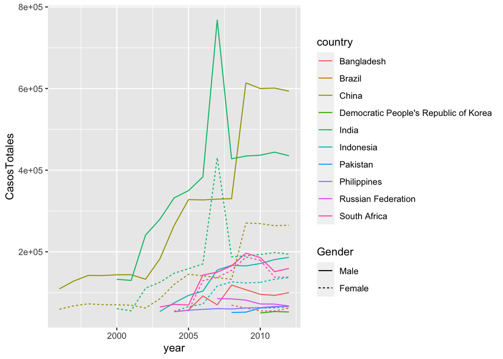

```r
na.omit(whoLimpio)  %>% group_by(country,year,Gender) %>% summarise(CasosTotales=sum(value),CasosPor100kHabi=sum(value)*100000/(population)) %>%
  filter(year>1995)  %>%  filter(CasosTotales>50000) %>%
 # filter(substr(country,1,2) == "Ba") %>%
ggplot(aes(x = year, y = CasosTotales)) +
  geom_line(aes(colour=country,linetype=Gender,  group=interaction(Gender, country)))
```

Aquí representamos la incidencia de tuberculosis de aquellos paises cuyo nombre empiece por la letra B:

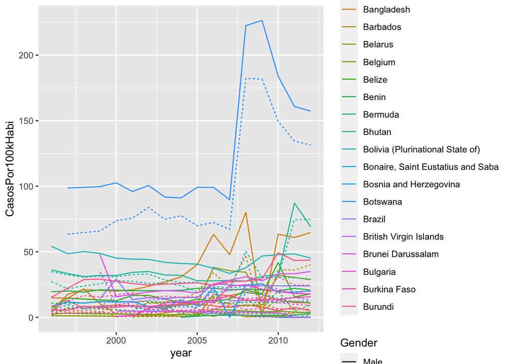

```r
na.omit(whoLimpio)  %>% group_by(country,year,Gender) %>%
  summarise(CasosTotales=sum(value),CasosPor100kHabi=sum(value)*100000/(population)) %>%
  filter(year>1995)   %>%
  filter(substr(country,1,1) == "B") %>%
  ggplot(aes(x = year, y = CasosPor100kHabi)) +
  geom_line(aes(colour=country,linetype=Gender,  group=interaction(Gender, country)))
```